# Northern Three Spatial Analyses (Inshore Marine Exploratory Data Analysis)

- Show All Code
- Hide All Code
- View Source

Author

Adam Shand

Published

April 15, 2024

**R Version**

For R session info at the time of rendering this script see Section 8.

# 1 Introduction

# 2 Script Set Up

This script requires multiple core spatial packages, all packages are loaded below.

```r
#load packages
library(tidyverse)
library(readxl)
library(glue)
library(here)
library(busdater)
library(reactable)
library(ggplot2)

#turn off scientific notation
options(scipen = 999)

#set a path to the data reading location
data_path <- here("data/dt_water-quality_inshore/raw/")

#establish what financial year we are looking at
current_fyear <- params$target_fyear

#get a date variable (this is important for naming as it is anticipated multiple runs of the script will be required).
date <- format(Sys.time(), "%Y-%m-%d")

#create a file path for the year of data that is being looked at
year_folder <- glue("{here()}/outputs/dt_water-quality_inshore_s1-eda/{current_fyear-1}-{current_fyear}_eda/")

#create that folder
dir.create(year_folder, recursive = T)

#create a file path to help with saving things, make sure to include date
save_path <- glue("{year_folder}/eda_conducted_on_{date}/")

#create folder
dir.create(save_path, recursive = T)

#create additional extension folders from this
dir.create(glue("{save_path}/spreadsheets/"))
dir.create(glue("{save_path}/graphs/"))
```

# 3 Load Data

Data for this script is provided in two spreadsheets: a metadata spreadsheet, and a master spreadsheet.

The metadata spreadsheet contains (for all current sites):

- Grouping information for each site (region, environment, zone, sub_zone, geographic_area, code),
- Location information for each site i.e., where the site is (lat, long)
- Supplier information (who provides the data),
- Alternative names the site might be known by,
- Water quality objective (WQO) information for each site,
- Limit of reporting (LOR) information for each site,
- The original source for WQO and LOR values,
- plus the above information for all historical sites.

The master spreadsheet contains:

- Codes for all data, to be cross checked against metadata,
- All sample data for all current sites for as far back as possible (~2019),
- All currently monitored variables,
- Units for each variable, to cross check against metadata,
- Peripheral variables as need to calculated main variables.

## 3.1 Metadata Spreadsheet

```r
#create list of sheets to target
target_sheets <- c("Current_Sites", "WQO", "LOR")

#create empty dataframe to hold metadata
site_metadata <- data.frame()

#get the total number of sheets excluding the first one (which is the README sheet)
for (i in 1:length(target_sheets)){

  #read in the target sheet
  temp_sheet <- read_excel(glue("{data_path}/dt_wq_inshore_metadata.xlsx"),
                           sheet = target_sheets[i], na = c("", "NA", "NULL", "null"))

  #if it is the first sheet(the "Current_Sites" sheet) then rename it to the main metadata variable
  if (i == 1){site_metadata <- temp_sheet |> select(-c(Site_Name, AKA))}

  else {#otherwise, pivot the data and then merge it onto the main metadata variable

    temp_sheet <- pivot_longer(temp_sheet, cols = 2:ncol(temp_sheet), #select data, then target columns
                               names_to = c(".value", "Indicator"), names_pattern = "([A-Za-z]+)_(.+)")
    #.value indicates this part of the col name defines the name of the output column (it overrides the "values_to" arg)
    #names_pattern = how to split. this has two groups marked by brackets: 1. any letter left of underscore, 2. everything else.

    #merge onto main
    site_metadata <- merge(site_metadata, temp_sheet)}

}

#convert LOR values to the correct units (for MMP indicators only)
site_metadata <- site_metadata |>
  mutate(LOR = case_when(Supplier == "MMP" & Indicator %in% c("NOX", "PN") ~ (LOR*14.01)/1000,
                        Supplier == "MMP" & Indicator %in% c("PP", "FRP") ~ (LOR*30.97)/1000,
                        T ~ LOR))

#add units of measure, direction of failure, and statistic used. These should be able to be crossed check against the human readable pages in the excel metadata spreadsheet if anything seems off
site_metadata <- site_metadata |>
  mutate(Units = case_when(Indicator == "Turbidity" ~ "NTU",
                           Indicator == "Secchi" ~ "m",
                           Indicator == "Chla" ~ "ug.L",
                           T ~ "mg.L"),
         Failure = case_when(Indicator == "Secchi" ~ "low", T ~ "high"),
         Stat = case_when(Indicator %in% c("Turbidity", "TP", "NOX") ~ "median", T ~ "mean"))

#clean up
rm(target_sheets, temp_sheet)
```

## 3.2 Master Data Spreadsheet

The master data sheet is built over a couple of stages:

### 3.2.1 Import Datasets

Each of the datasets needs to be imported, they are stored in separate sheets so must be read in separately.

!!! need to change this, now do manually - Note the logic to remove the < symbol. These values are handled later using the metadata information. - Note the replacement of “aturat” (catches any variation of “saturated” (caps of otherwise)) with the value 100. - Note dates: some are provided as date_time, others, only date. The edit drops time and does not affect rows without time attached.

```r
#get a variable listing all available sheets
sheets <- excel_sheets(glue("{data_path}/dt_wq_inshore_data_master.xlsx"))

#get the total number of sheets excluding the first one (which is the README sheet)
for (i in 2:length(sheets)){

  #read in the target sheet
  temp_sheet <- read_excel(glue("{data_path}/dt_wq_inshore_data_master.xlsx"),
                           sheet = sheets[i], na = c("", "NA", "NULL", "null"),
                           guess_max = 5000) |> #force guess_max to 5000 so loggers don't get read as boolean
    select(-Site_Name) #drop site name immediately as it is an uncontrolled variable only included for the human reader

  #assign the correct name, remove < symbols, and convert columns to numeric
  assign(sheets[i], temp_sheet |>
           mutate(#across(everything(), ~ str_replace(.x, "<", "")), #this should now be obsolete
                  across(c(3:ncol(temp_sheet)), as.numeric),
                  Date = Date + seconds(1), #add one second to avoid date-time error
                  Date = ymd_hms(Date), FY = get_fy(Date), .after = Date) |>
           filter(FY > 2012,
                  FY <= current_fyear)) #to allow for specific reporting year targeting
}

#clean up
rm(temp_sheet, i)
```

### 3.2.2 Special Treatment of Datasets

Some of the datasets have unique treatments that they received before they can be combined together, for example, below we calculate mg/L of NOX, PN and PP from umol/L.

```r
#convert data
MMP_Grab <- MMP_Grab |> mutate(NOX_mg.L = ((NO2_umol.L + NO3_umol.L)*14.01)/1000,
                               PN_mg.L = (PN_umol.L*14.01)/1000,
                               PP_mg.L = (PP_umol.L*30.97)/1000,
                               FRP_mg.L = (DIP_umol.L*30.97)/1000, #FRP and DIP are equivalent and stated to be measuring the same thing)
                               .keep = "unused")

#rename old POTL codes
POTL_Grab <- POTL_Grab |> mutate(Code = case_when(Code == "CB01" ~ "CB15", Code == "CB02" ~ "CB16",
                                                  Code == "IH108" ~ "SB01", Code == "PC14" ~ "P05",
                                                  T ~ Code))
```

### 3.2.3 Bind Datasheets

now all sheets can be combined and provided with metadata and the finishing touches added. This includes adjusting values that are at or below the limit of reporting, and making sure logger and grab data are complimentary.

```r
#Each of the spreadsheets (now aligned) can be given the same process
inshore_wq <- bind_rows(mget(sheets[2:length(sheets)]))

inshore_wq_all <- inshore_wq |>
  pivot_longer(cols = 4:ncol(inshore_wq), names_to = "Indicator", values_to = "Values") |> #pivot data longer
  separate_wider_regex("Indicator", c("Indicator" = ".*", "_", "Units" = ".*")) |> #split names into indicator and units
  mutate(Date = ymd(substr(Date, 1, 10))) |> #drop time so we can get daily means
  group_by(Code, Date, FY, Indicator, Units) |>
  summarise(Values = mean(Values)) |> ungroup() |>  #get daily mean
  left_join(site_metadata) |>
  filter(!is.na(Values))

#clean up
rm(list = sheets[2:length(sheets)], sheets)
```

# 4 QA/QC Checks

We can now take this opportunity to perform the required QA/QC Checks, at the moment this includes:

- Units
- Locations and Codes
- LOR/value comparison
- LOR/WQO comparison

Please add more as you see fit.

## 4.1 Unit Check

First we will check the units, we are looking to detect if any of the indicators have more than one set of units assigned.

```r
#group by indicator and units
unit_check <- inshore_wq_all |>
  group_by(Indicator, Units) |>
  summarize(.groups = "drop")

#then check if the number of indicators is equal to the number of indicator-unit pairs
if (length(unique(unit_check$Indicator)) == n_distinct(unit_check)){

  print("Test passed. No erroneous indicator units.")

  rm(unit_check)

} else {

  #save csv
  write_csv(unit_check, glue("{save_path}/spreadsheets/unit_check.csv"))

stop("Test fail, an indicator has data with two different units. Raw data might be provided with two
     different units, or the units listed in the metadata may not match the master data. Review the
     'unit_check' table for more information.")
}
```

```
[1] "Test passed. No erroneous indicator units."
```

## 4.2 Locations and Codes

We will check the number of locations found in the dataset matches what we expect to find (which for inshore is 8 unique geographic areas and 20 unique codes (sites)).

```r
#group by the different levels of location
location_check <- inshore_wq_all |>
  group_by(Region, Environment, Zone, Sub_Zone, Geographic_Area) |>
  summarize(.groups = "drop")

#get the number of locations that are expected
num_locs <- ifelse(current_fyear <= 2020, 7, 8)

#then check if we have the right number of locations
if (nrow(location_check) == num_locs & !any(is.na(location_check))){

  print("Test passed. Correct number of locations.")

  rm(location_check)

} else {

  #save csv
  write_csv(location_check, glue("{save_path}/spreadsheets/location_check.csv"))

stop("Test fail, currently the DT report should have 8 unique geographic areas, please cross check if
     there are locations missing, or if there have been new locations added. Review the
     'location_check' table for more information.")
}
```

```
[1] "Test passed. Correct number of locations."
```

```r
#group by geographic areas and code
code_check <- inshore_wq_all |>
  group_by(Geographic_Area, Code) |>
  summarize(.groups = "drop")

#get the number of codes that are expected
num_codes <- ifelse(current_fyear <= 2020, 18, 20)

#then check if we have the right number of geographic areass and codes
if (nrow(code_check) == num_codes & !any(is.na(code_check))){

  print("Test passed. Correct number of sites.")

  rm(code_check)

} else {

  #save csv
  write_csv(code_check, glue("{save_path}/spreadsheets/code_check.csv"))

stop("Test fail, currently the DT report should have 20 unique codes(sites), please cross check if
     there are codes missing, or if there have been new codes added. Review the 'code_check' table
     for more information.")
}
```

```
[1] "Test passed. Correct number of sites."
```

## 4.3 LOR/Value Comparison

We will now compare the LOR values against the concentration values recorded in the master spreadsheet. What we are trying to spot is how many of the concentrations values are half (or less) of the LOR. If lots of the concentration values are half the LOR then this is a warning sign that the LOR is likely not low enough and not fit for purpose.

```r
#check how many values are half of the LOR compared to the total number of values for the reporting period
value_lor_check <- inshore_wq_all |>
  filter(FY == current_fyear) |>
  mutate(`Value_Halved?` = case_when(Values <= LOR ~ "Value_Halved",
                                     T ~ "Value_Unchanged")) |>
  group_by(Code, Indicator, `Value_Halved?`) |>
  summarise(Count = n(), .groups = "drop") |>
  pivot_wider(names_from = `Value_Halved?`, values_from = Count) |>
  filter(!is.na(Value_Halved))

if (!any(value_lor_check$Value_Halved > value_lor_check$Value_Unchanged)){

  print("Minimal values were changed.")

  rm(value_lor_check)

} else {

  #save the value lor check table
  write_csv(value_lor_check, glue("{save_path}/spreadsheets/value_lor_check.csv"))

warning("At >= one site, there are more values that have been changed to half the LOR than have
been left unchanged. This is not inherently wrong, but should be double checked. Check the
'value_lor_check' table for a list of all sites with changed values.")

}
```

```
Warning: At >= one site, there are more values that have been changed to half the LOR than have
been left unchanged. This is not inherently wrong, but should be double checked. Check the
'value_lor_check' table for a list of all sites with changed values.
```

## 4.4 LOR/WQO Comparison

Finally we will compare the LOR and WQO values. This an important comparison as if the WQO value is equal to or less than the LOR value it becomes impossible to determine if the actual concentration values are equal to or less than the WQO value. For example:

- If LOR = 1,
- And WQO = 0.5,
- The lowest a concentration can be recorded is <1 (half LOR).
- Therefore, is the concentration (<1) lower than the WQO (0.5)?
- It is impossible to know.

For any site that is flagged, the offending indicator will be removed.

```r
#check if the LOR is equal to or greater than the WQO, whilst also checking if any values are also in this range
wqo_lor_check_p1 <- inshore_wq_all |>
  filter(FY == current_fyear, Indicator != LOR) |> #this gets current year and ignore FRP
  mutate(Comparison = case_when(LOR >= WQO & Values > LOR ~ "Val_Warn",
                                LOR >= WQO & Values <= LOR ~ "Val_Fail",
                                T ~ "Val_Pass")) |>
  group_by(Code, Indicator, LOR, WQO, Comparison) |>
  summarise(Count = n(), .groups = "drop") |>
  pivot_wider(names_from = Comparison, values_from = Count)

#check if warning or fail values exists
if (any("Val_Fail" %in% colnames(wqo_lor_check_p1))){

  #conduct checks for each indicator to determine if enough samples are above LOR/WQO to be allowed to use the site
  wqo_lor_check_p2 <- wqo_lor_check_p1 |>
    mutate(across(everything(), ~ replace_na(.x, 0))) |>
    group_by(Code, Indicator) |>
    summarise(across(contains("Val"), ~ sum(.x)),
              Keep_Site = case_when(Val_Fail < (if(exists("wqo_lor_check_p1$Val_Warn")){Val_Warn + Val_Pass} else {Val_Pass}) ~ "Keep",
                                    T ~ "Remove"), .groups = "drop") |>
    ungroup()

  #save the lor WQO check table
  write_csv(wqo_lor_check_p2, glue("{save_path}/spreadsheets/wqo_lor_check.csv"))

  #check if any sites need to be removed
  if (!any(str_detect(wqo_lor_check_p2$Keep_Site, "Rem"))){

    #if no sites need to be removed save the data
    write_csv(inshore_wq_all, glue("{save_path}/spreadsheets/inshore_wq_all.csv"))

    print("Test passed. No sites need to be removed.")

  } else { #if warning and fail values outnumber values that pass then remove those rows

    #to remove problem sites create a table containing the code-indicator pair of any failed sites
    removal_table <- wqo_lor_check_p2 |>
      filter(Keep_Site == "Remove") |>
      select(Code, Indicator)

    #use the full dataset to add all information about the code-indicator pair of any failed sites
    removal_table <- semi_join(filter(inshore_wq_all, FY == current_fyear), removal_table, by = join_by(Code, Indicator))

    #subtract from the main table, any rows that appear in the removal table
    inshore_wq_removed <- suppressMessages(anti_join(inshore_wq_all, removal_table))

    #save the before and after site removal tables
    write_csv(inshore_wq_all, glue("{save_path}/spreadsheets/inshore_wq_all_pre_site_removal.csv"))
    write_csv(inshore_wq_removed, glue("{save_path}/spreadsheets/inshore_wq_all_post_site_removal.csv"))

    #save the table that lists what was actually removed
    write_csv(removal_table, glue("{save_path}/spreadsheets/inshore_wq_all_sites_removed.csv"))

    warning("At >= one site, the LOR is >= WQO AND >= 50% of the values are <= LOR. This means at
    least one site has failed. The offending sites and indicators have been removed, however the
    code will provide a warning here so the user is aware and can inspect the cause of the issue.")

  }

} else {#if there are no fail values

  #save the dataset
  write_csv(inshore_wq_all, glue("{save_path}/spreadsheets/inshore_wq_all.csv"))

  print("Test passed. No sites need to be removed.")

}
```

The code chunk above has automatically removed the offending indicators from the offending sites. Now, in the code chunk below, we will overwrite the main inshore dataset with the dataset we just created that has some values removed.

```r
#if data needed to be removed, store the main dataset as "old" and assign the updated dataset back to the main dataset
if (exists("inshore_wq_removed")){

  inshore_wq_pre_removal <- inshore_wq_all

  inshore_wq_all <- inshore_wq_removed}
```

# 5 EDA Checks

After some mostly automated QA/QC we will now conduct some exploratory data analysis to see if we can spot anything wrong with this years data.

```r
inshore_wq_cy <- inshore_wq_all |> filter(FY == current_fyear)
```

## 5.1 Histograms

Next we will create histograms for this years data, e.g.:

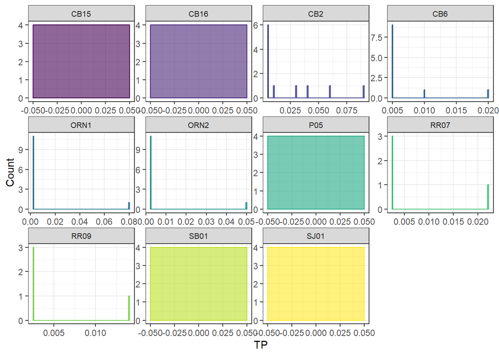

```r
for (i in unique(inshore_wq_cy$Indicator)){#for each indicator

  #get only that indicator
  target_data <- inshore_wq_cy |> filter(Indicator == i)

  #plot data
  temp_plot <- ggplot(target_data, aes(x = Values, color = Code, fill = Code)) +
    geom_histogram(alpha = 0.6, bins = 100) +
    viridis::scale_fill_viridis(discrete = T) +
    viridis::scale_colour_viridis(discrete = T) +
    theme_bw() +
    theme(legend.position="none",
          panel.spacing = unit(0.1, "lines"),
          strip.text.x = element_text(size = 8)) +
      xlab(glue("{i}")) +
      ylab("Count") +
    facet_wrap(~Code, scales = "free")

  #save to file
  ggsave(glue("{save_path}/graphs/{i}_histogram.png"))

}

#show last plot
temp_plot
```

## 5.2 Boxplots

and as a box plots, e.g.:

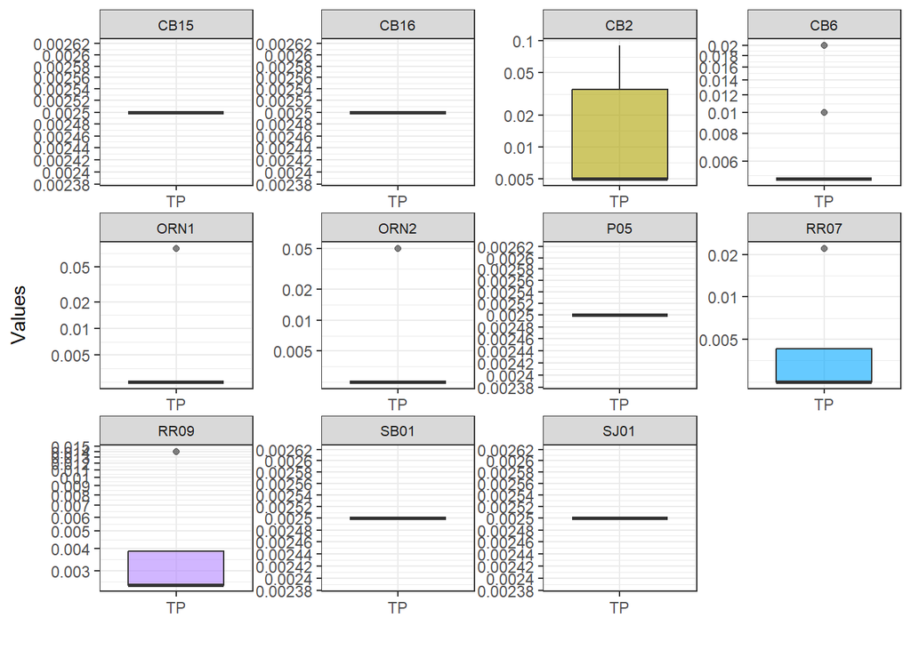

```r
#create custom log function for tick breaks
base_breaks <- function(n = 10){
    function(x) {
        axisTicks(log10(range(x, na.rm = TRUE)), log = TRUE, n = n)
    }
}

for (i in unique(inshore_wq_cy$Indicator)){#for each indicator

  #get only that indicator
  target_data <- inshore_wq_cy |> filter(Indicator == i)

  #plot data
  temp_plot <- ggplot(target_data, aes(x = Indicator, y = Values, fill = Code)) +
    geom_boxplot(alpha = 0.6) +
    theme_bw() +
    theme(legend.position="none",
          panel.spacing = unit(0.1, "lines"),
          strip.text.x = element_text(size = 8)) +
    xlab("") +
    scale_y_continuous(trans = scales::log_trans(), breaks = base_breaks(),
                   labels = prettyNum) +
    facet_wrap(~Code, scales = "free")

  #save to file
  ggsave(glue("{save_path}/graphs/{i}_boxplot.png"))

}

#show last plot
temp_plot
```

## 5.3 Lineplots

and some line plots, e.g.:

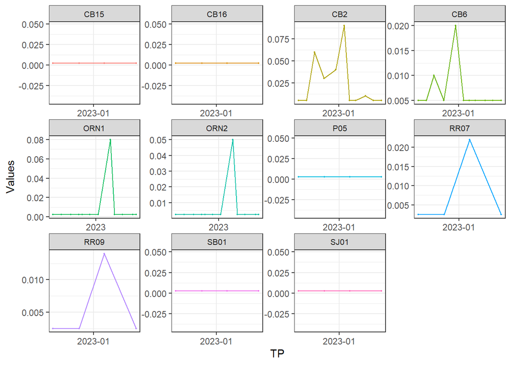

```r
for (i in unique(inshore_wq_cy$Indicator)){#for each indicator

  #get only that indicator and convert from ymd_hms to ymd only
  target_data <- inshore_wq_cy |> filter(Indicator == i) |> mutate(Date = ymd(substr(Date, 1, 10)))

  #plot data
  temp_plot <- ggplot(target_data, aes(x = Date, y = Values, color = Code)) +
    geom_line(na.rm = T) +
    geom_point(size = 0.4) +
    theme_bw() +
    theme(legend.position="none",
          panel.spacing = unit(0.1, "lines"),
          strip.text.x = element_text(size = 8)) +
    xlab(glue("{i}")) +
    scale_x_date(breaks = scales::pretty_breaks(n = 2))+
    facet_wrap(~Code, scales = "free")

  #save to file
  ggsave(glue("{save_path}/graphs/{i}_lineplot.png"))

}

#show last plot
temp_plot
```

# 6 Action Outstanding EDA

Earlier in the script we conducted preliminary QA/QC and were also able to automated some of the common actions required. However after conducting preliminary EDA there is no easy way to automate the actions required by the findings of this. Thus this section is the custom response to the EDA findings that were determined for the **2023** (financial year) data.

**It is important to note that this section should manually be rewritten each year to specifically address the EDA finding of the year.**

To make sure we don’t miss anything we will go indicator by indicator:

```r
print("This year, there were several Turbidity values dectected by the S2 logger that were more than 1000 times greater than the preceeding and following recorded values. These values (5 total values) were removed from the dataset.")
```

```
[1] "This year, there were several Turbidity values dectected by the S2 logger that were more than 1000 times greater than the preceeding and following recorded values. These values (5 total values) were removed from the dataset."
```

# 7 Save Data

Now that all QA/QC and EDA actions are completed we can save the processed data in the main data folder, ready for the main analysis script. This save step is quite important as we dont want to overwrite old dataset prematurely, thus we will include the year of data that was targeted for the eda checks.

Also, once again it should be noted that the dataset may have had some values removed during the LOR/WQO QA/QC step. If this is the case the dataset will contain an extra bit of information in the file name stating as such.

```r
if (exists("inshore_wq_removed")) {# a removed and non-removed set exists, save both

  #save the data with the removed sites
  write_csv(inshore_wq_all,
            glue("{here()}/data/dt_water-quality_inshore/processed/{current_fyear-1}-{current_fyear}_inshore_wq_all_sites_removed.csv"))

  #save the original without the removed sites - this is useful for inspecting at a later date
  write_csv(inshore_wq_pre_removal,
            glue("{here()}/data/dt_water-quality_inshore/processed/{current_fyear-1}-{current_fyear}_inshore_wq_all_pre_removal.csv"))

} else {#otherwise just save the one

  write_csv(inshore_wq_all,
            glue("{here()}/data/dt_water-quality_inshore/processed/{current_fyear-1}-{current_fyear}_inshore_wq_all.csv"))

}
```

# 8 Session Info

Below is the session info at the time of rendering this script. Of greatest importance is to note the R version, and the “other attached packages” as these are the most significant drivers of success/failure. It is also good to check the “attached base packages” and “loaded via a namespace” packages as well. To check your session info use `sessionInfo()`.

[session information not shown]